# Lecture 16 — Classical Object Detection

Lecture 16

Kaveh Fathian

Computer Science Department, Colorado School of Mines

## Learning Objectives

By the end of this lecture, you should be able to:

- Explain why raw pixels are poor features for pedestrians, and describe a window with HOG: gradient histograms in cells, normalized over blocks.
- Classify a window with a linear SVM on its HOG vector.
- Turn a classifier into a detector with sliding windows, an image pyramid, and non-maximum suppression (IoU).
- Run the Dalal–Triggs pedestrian detector in OpenCV, step by step and with `detectMultiScale`.
- Evaluate a detector with precision, recall, the precision–recall curve, and AP (and mAP).
- Explain how Viola–Jones makes face detection fast: Haar features, the integral image, AdaBoost, and the attentional cascade.
- Compute a rectangle sum and a Haar feature from the integral image, and run AdaBoost on a small example.
- Detect faces with OpenCV’s `CascadeClassifier`, and recognize its limits.

# Pedestrian Classification

## Pedestrian Classification

- **Pedestrian classification:** is there a pedestrian in a 64 × 128 window or not?
- Pedestrians look very different: pose, viewpoint, clothing, occlusion and background clutter.
- The same pedestrian also changes with lighting, position, rotation and size in the window.
- These changes alter the pixel values far more than they alter the person, so KNN or an SVM on raw pixels works poorly.
- We need **features** that stay the same under these changes but still separate pedestrians from everything else.

[figure not shown]

## Histogram of Oriented Gradients (HOG)

- **Idea:** describe a window by its edge directions. The shape of a person is in the gradients, not in the pixel values.

**HOG Descriptor**

1. Compute the gradient magnitude and angle at every pixel.
2. Split the 64 × 128 window into 8 × 8-pixel **cells**.
3. For each cell, a **histogram of gradient angles**: 9 bins over 0°–180°; each pixel adds its magnitude to the bin of its angle.
4. Group 2 × 2 cells into a **block** and normalize it, so lighting changes cancel out.
5. Concatenate all blocks into the **HOG vector**.

[figure not shown]

## HOG Vector

- A window has 7 × 15 = 105 **blocks** of 2 × 2 cells. Neighboring blocks overlap by one cell.
- Each block: its 4 cell histograms (36 numbers), normalized to unit length.
- **HOG vector:** all normalized blocks, one after another: 105 × 36 = **3,780 numbers**.

[figure not shown]

## HOG + Linear SVM Classifier

- Classifier: a **linear SVM** on the HOG vector $\mathbf{x}$ of the window:

$$\bbox[border: 2px solid #c53030; padding: 2px 6px]{s = \mathbf{w}^\top \mathbf{x} + b}\;\;{\color{#c53030}{\textbf{pedestrian if } s > 0}}$$

- Trained on HOG vectors of pedestrian windows (positive) and background windows (negative).
- OpenCV includes a trained classifier: $\mathbf{w}$ (3,780 weights) and $b$.
- Positive weights: where the SVM expects edges of a person. Negative weights: edges that suggest background.

[figure not shown]

# From Classification to Detection

## Pedestrian Detection

- **Pedestrian detection:** draw a bounding box around every person in the image.
- **Idea:** check every window. Slide the 64 × 128 window over the image, and classify each window.
- Problems, and how to solve them:
  - Too many windows: move the window 8 pixels at a time (the **stride**). This image still has **7,524 windows**.
  - People come in many sizes, but the window has one size: **image pyramid**.
  - A person gives positive scores in several overlapping windows: keep one box per person (**non-maximum suppression**).

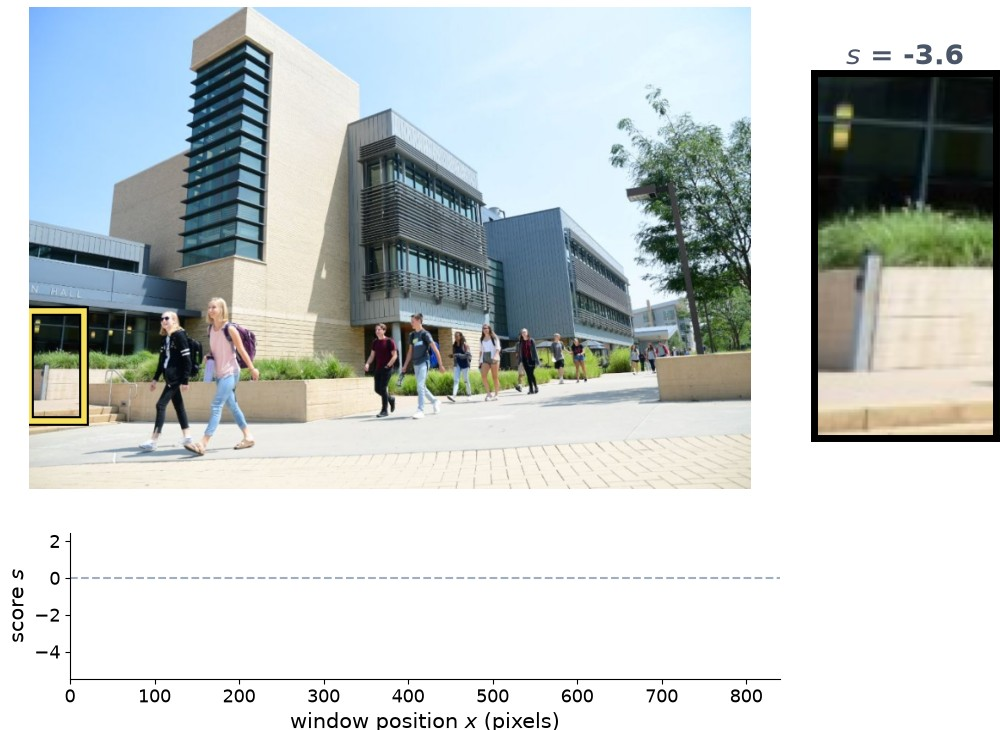

## Image Pyramids

- People appear at many sizes, but the window has one size.
- **Image pyramid:** shrink the image a little at a time (by a factor of 1.05), and slide the same window over every level.
- Large people fit the window at small levels. Smaller people fit at larger levels.
- A window found at scale $s$ is a box $1/s$ times larger in the original image.
- This image: 34 levels and **63,958 windows** in total.

[figure not shown]

## Non-Maximum Suppression

- **Intersection over union (IoU):** how much two boxes overlap.

$$\bbox[border: 2px solid #c53030; padding: 2px 6px]{\text{IoU}(A, B) = \frac{\text{area}(A \cap B)}{\text{area}(A \cup B)}}\;\;{\color{#c53030}{\textbf{IoU}}}$$

**Non-Maximum Suppression (NMS)**

1. Drop all windows with a score below a threshold (e.g., $s < 0.5$).
2. Pick the highest-scoring remaining window and add it to the **detections**.
3. Delete all remaining windows that overlap it with IoU > 0.3 (they show the same person).
4. Repeat steps 2–3 until no windows remain.

[figure not shown]

## Dalal–Triggs Pedestrian Detector

**Dalal–Triggs Detector**

1. Build an image pyramid.
2. Slide a 64 × 128 window over every level.
3. Compute the window’s HOG vector $\mathbf{x}$.
4. Linear SVM score: $s = \mathbf{w}^\top \mathbf{x} + b$.
5. Keep windows with $s$ above a threshold, and apply NMS.
- The same classifier, applied to every window at every scale, turns classification into detection.

[figure not shown]

## Dalal–Triggs Detector in Code

- `HOGDescriptor()`: the Dalal–Triggs settings (64 × 128 window, 8 × 8 cells, 2 × 2-cell blocks, 9 bins).
- `getDefaultPeopleDetector()`: the trained $\mathbf{w}$ and $b$.
- `groupThreshold=0`: all windows with $s > 0$, at every scale. `NMSBoxes` then applies NMS.
- **Full detector:** `detectMultiScale` alone runs every step, but merges overlapping windows with its own grouping instead of NMS.

```python
hog = cv2.HOGDescriptor()
svm = cv2.HOGDescriptor_getDefaultPeopleDetector()
w, b = svm[:-1], svm[-1]             # 3,780 weights, bias

# Classify one 64 x 128 window
window = cv2.resize(image[y0:y1, x0:x1], (64, 128))
x = hog.compute(window)              # HOG vector
s = w @ x + b                        # pedestrian if s > 0

# Detect: all windows with s > 0, then NMS
hog.setSVMDetector(svm)
boxes, scores = hog.detectMultiScale(
    image, winStride=(8, 8), scale=1.05, groupThreshold=0)
keep = cv2.dnn.NMSBoxes(boxes, scores, 0.5, 0.3)
```

```python
# Full detector in one call
hog = cv2.HOGDescriptor()
hog.setSVMDetector(
    cv2.HOGDescriptor_getDefaultPeopleDetector())
boxes, scores = hog.detectMultiScale(
    image, winStride=(8, 8), scale=1.05)
```

## Dalal–Triggs Detector: Full Code

```python
import cv2
import numpy as np
import matplotlib.pyplot as plt

image = cv2.imread("assets/16_classical_detection/people.jpg")

# 1. HOG with the Dalal–Triggs settings, and OpenCV's trained linear SVM.
hog = cv2.HOGDescriptor()
print("HOG vector length:", hog.getDescriptorSize())          # 3,780
svm = cv2.HOGDescriptor_getDefaultPeopleDetector()            # 3,780 weights w, then the bias b
w, b = svm[:-1], svm[-1]
hog.setSVMDetector(svm)

# 2. Image pyramid (scale 1.05), sliding windows (stride 8) and SVM scores.
#    groupThreshold=0 returns every window with s > 0, without merging.
boxes, scores = hog.detectMultiScale(image, winStride=(8, 8), scale=1.05, groupThreshold=0)
scores = scores.ravel()
print("windows with s > 0:", len(boxes))

# 3. Non-maximum suppression: drop scores below 0.5, then remove boxes with IoU > 0.3
#    with a higher-scoring box.
keep = np.ravel(cv2.dnn.NMSBoxes(boxes.tolist(), scores.tolist(), 0.5, 0.3))
boxes, scores = boxes[keep], scores[keep]
print("detections after NMS:", len(boxes))

# 4. Classify one window by hand: s = w . x + b for the window of the best detection.
x0, y0, bw, bh = boxes[np.argmax(scores)]
window = cv2.resize(image[y0:y0 + bh, x0:x0 + bw], (64, 128), interpolation=cv2.INTER_AREA)
x = hog.compute(window)                                       # HOG vector of the window
print(f"score of the window: {w @ x + b:.1f}")

# 5. Draw the detections and their scores.
out = cv2.cvtColor(image, cv2.COLOR_BGR2RGB)
for (bx, by, bw, bh), s in zip(boxes, scores):
    cv2.rectangle(out, (bx, by), (bx + bw, by + bh), (0, 200, 0), 2)
    cv2.putText(out, f"{s:.1f}", (bx + 3, by + 18), cv2.FONT_HERSHEY_SIMPLEX, .6, (0, 200, 0), 2)
plt.imshow(out)
plt.axis("off")
plt.show()
```

# Evaluating Detectors

## Precision and Recall

- Compare the detections with the **ground-truth boxes** (labeled by hand).
- **True positive (TP):** a detection with IoU ≥ 0.5 with a ground-truth box. Each ground-truth box can be matched only once.
- **False positive (FP):** any other detection.
- **False negative (FN):** a person with no matching detection.

$$\bbox[border: 2px solid #c53030; padding: 2px 6px]{\text{precision} = \frac{TP}{TP + FP}}\;\;{\color{#c53030}{\begin{array}{l}\textbf{how many}\\ \textbf{detections}\\ \textbf{are correct}\end{array}}}$$

$$\bbox[border: 2px solid #c53030; padding: 2px 6px]{\text{recall} = \frac{TP}{TP + FN}}\;\;{\color{#c53030}{\begin{array}{l}\textbf{how many}\\ \textbf{people}\\ \textbf{are found}\end{array}}}$$

[figure not shown]

TP = 1, FP = 1, FN = 1: precision = 0.50, recall = 0.50

## Precision–Recall Curve

- Keep only the detections whose score $s$ is above a threshold.
- **High threshold:** few detections, mostly correct: high precision, low recall.
- **Low threshold:** more people found, but more false positives: higher recall, lower precision.
- **Precision–recall curve:** precision and recall as the threshold goes down (also below 0), until recall stops increasing.

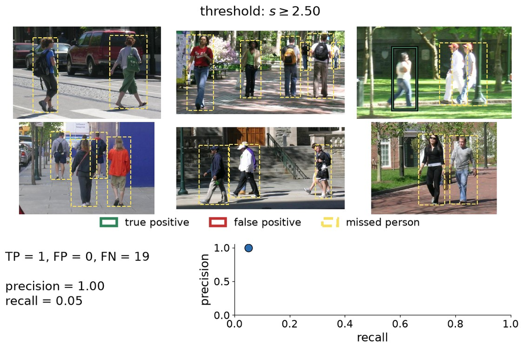

## Average Precision (AP)

- One number for the whole curve: the **area under the precision–recall curve**.

$$\bbox[border: 2px solid #c53030; padding: 2px 6px]{\text{AP} = \text{area under the curve}}\;\;{\color{#c53030}{\begin{array}{l}\textbf{higher}\\ \textbf{is better}\end{array}}}$$

- Dalal–Triggs on all 170 Penn-Fudan images: **AP = 0.34**. Even with every window, recall stops at 0.72.
- **mAP (mean average precision):** with several object classes, compute the AP of each class and take the mean.

[figure not shown]

# Viola–Jones Face Detection

## Viola–Jones Face Detector

- **Face detection:** draw a box around every face.
- Same approach as for pedestrians: classify every window (24 × 24 pixels) at every scale of an image pyramid.
- Faces are rare and windows are many, so each window must be classified **very fast**.
- Four ideas make it fast:
  1. **Haar features**
  2. **Integral image**
  3. **Boosting**
  4. **Attentional cascade**.

[figure not shown]

## Haar Features

- A **Haar feature** is a pattern of adjacent white and black rectangles.
- Its value: the sum of the pixels under white minus the sum of the pixels under black, which measures a brightness difference.
- Every position and size of the five types fits in a 24 × 24 window: **162,336 features**.
- Viola–Jones uses only these five types (upright rectangles).

[figure not shown]

## Integral Image

- **Integral image:** each pixel holds the sum of all pixels above and to the left of it (including itself).

$$\bbox[border: 2px solid #c53030; padding: 2px 6px]{\text{sum} = D - B - C + A}\;\;{\color{#c53030}{\textbf{4 lookups}}}$$

- With the integral image, any rectangle sum takes 4 lookups, and any Haar feature only a few (6–9), whatever its size.
- Bottom: a two-rectangle feature. Its rectangles share 2 corners: 6 lookups.

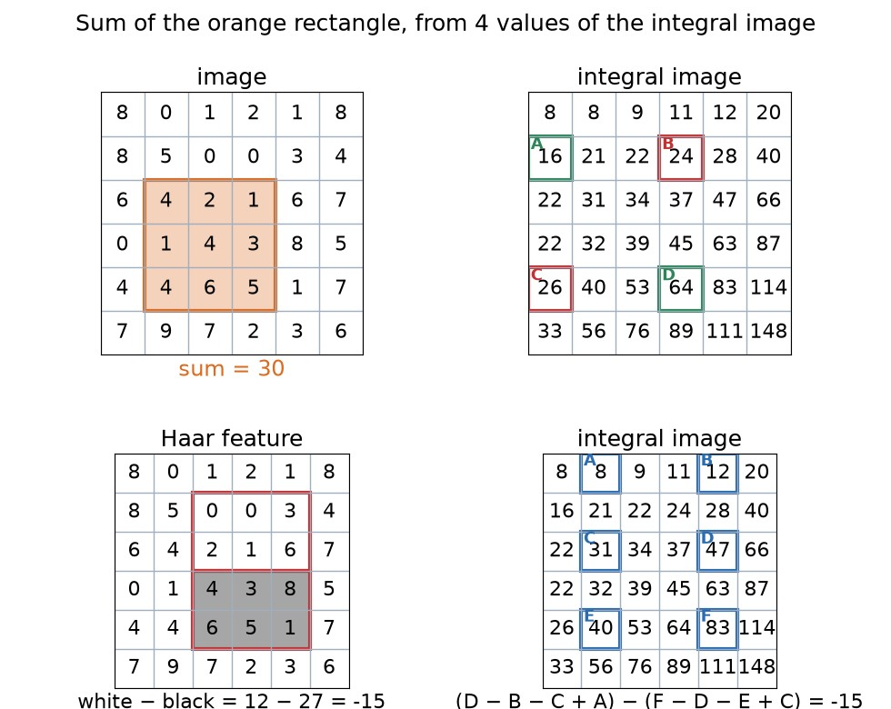

## AdaBoost

- **Decision stump** $h$: threshold one feature, e.g., $h(\mathbf{x}) = +1$ if $x_1 > 0.4$, else $-1$. In 2D: a vertical or horizontal line.

**AdaBoost**

1. Same weight for all $n$ points: $w_i = 1/n$.
2. Pick the stump $h_t$ with the smallest weighted error $\varepsilon_t$ (total weight of its wrong points).
3. Its vote: $\alpha_t = \frac{1}{2}\ln\frac{1 - \varepsilon_t}{\varepsilon_t}$.
4. Wrong points: weight $\times\, e^{\alpha_t}$. Correct points: $\times\, e^{-\alpha_t}$. Normalize.
5. Repeat 2–4. Final: $H(\mathbf{x}) = \text{sign}\big(\sum_t \alpha_t h_t(\mathbf{x})\big)$.
- **Stop:** after a set number of rounds, or once accurate enough (here: no mistakes after 3 rounds).

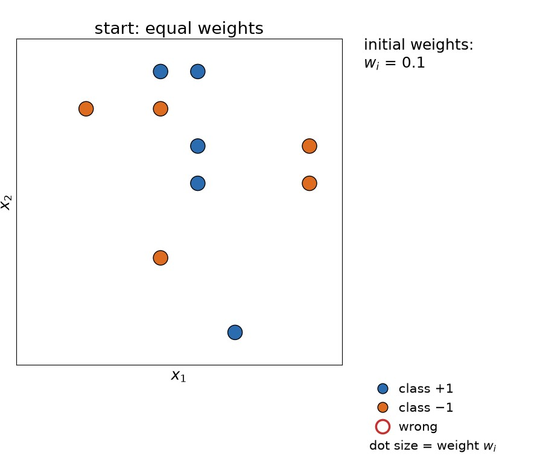

## Boosting with Haar Features

- **Weak classifier:** a decision stump on one Haar feature value.
- **Training (once):** each boosting round adds the best of the 162,336 features. A stage stops when it meets its target. Viola–Jones in OpenCV keeps 2,913 features in total.
- **Detection:** only these features are computed.
- The first two features of OpenCV’s face cascade:
  - eyes darker than the forehead and cheeks;
  - bridge of the nose brighter than the eyes.

[figure not shown]

## Attentional Cascade

- **Most windows are clearly not faces: reject them early, with only a few features**.
- **Cascade:** a chain of boosted classifiers that grow stronger. A 24 × 24-pixel window is a face only if it passes every stage.
- Viola–Jones in OpenCV: 25 stages; stage 1 has 9 features, stage 25 has 200.
- Example: each stage keeps 99.5% of faces and passes 50% of non-faces:
  - Faces kept: $0.995^{25} \approx 88\%$
  - Non-faces passed: $0.5^{25} \approx 3 \times 10^{-8}$

[figure not shown]

## Viola–Jones in Code

- `CascadeClassifier(file)`: loads a trained cascade.
- `detectMultiScale(gray, scaleFactor, minNeighbors)`: pyramid, sliding window and cascade.
- `minNeighbors`: keep only places with at least this many overlapping detections, and merge them into one box (instead of NMS).
- Finds only **frontal, upright** faces.
- OpenCV 5 doesn’t include the trained cascades: download them from [OpenCV’s GitHub](https://github.com/opencv/opencv/tree/4.x/data/haarcascades).

```python
cascade = cv2.CascadeClassifier(
    "haarcascade_frontalface_default.xml")
gray = cv2.cvtColor(image, cv2.COLOR_BGR2GRAY)
faces = cascade.detectMultiScale(
    gray, scaleFactor=1.1, minNeighbors=5)  # (x, y, w, h)
```

[figure not shown]

## Viola–Jones: Full Code

```python
import time
import xml.etree.ElementTree as ET

import cv2
import matplotlib.pyplot as plt

# OpenCV 5 doesn't include the trained cascades. Download haarcascade_frontalface_default.xml from
# https://github.com/opencv/opencv/tree/4.x/data/haarcascades
folder = "assets/16_classical_detection/"
cascade_file = folder + "haarcascade_frontalface_default.xml"
image = cv2.imread(folder + "faces.jpg")

# 1. The trained cascade: stages and features per stage (from the .xml file).
stages = ET.parse(cascade_file).getroot()[0].find("stages")
sizes = [int(s.find("maxWeakCount").text) for s in stages]
print(f"{len(sizes)} stages, {sum(sizes)} features; first stages: {sizes[:3]}")

# 2. Detect: image pyramid (scale 1.1), sliding 24 x 24 window, cascade, and merging of
#    overlapping detections (at least 5 neighbors).
cascade = cv2.CascadeClassifier(cascade_file)
gray = cv2.cvtColor(image, cv2.COLOR_BGR2GRAY)
t0 = time.perf_counter()
faces = cascade.detectMultiScale(gray, scaleFactor=1.1, minNeighbors=5)
print(f"{len(faces)} faces in {time.perf_counter() - t0:.1f} s")

# 3. Draw the detections.
out = cv2.cvtColor(image, cv2.COLOR_BGR2RGB)
for x, y, w, h in faces:
    cv2.rectangle(out, (x, y), (x + w, y + h), (0, 200, 0), 2)
plt.imshow(out)
plt.axis("off")
plt.show()
```

## Key Takeaways

- **HOG** describes a window by its edge directions: gradient histograms in 8 × 8 cells, normalized over 2 × 2-cell blocks. A **linear SVM** scores it: $s = \mathbf{w}^\top \mathbf{x} + b$.
- **Classification → detection:** classify every window at every level of an **image pyramid**, then **NMS** keeps one box per object.
- A detection is a **true positive** if its IoU with a ground-truth box is ≥ 0.5. Lowering the threshold trades **precision** for **recall**. **AP** is the area under the precision–recall curve; **mAP** is its mean over classes.
- **Viola–Jones** makes each window cheap: **Haar features** are brightness differences of rectangles, computed in a few lookups with the **integral image** ($D - B - C + A$).
- **AdaBoost** combines weak stumps: each round picks the stump with the lowest weighted error, gives it a vote $\alpha_t$, and increases the weight of its mistakes.
- The **attentional cascade** rejects most windows in the first stages, with only a few features. Only face-like windows reach the later stages.
- Both detectors use **hand-designed features**; neural networks learn the features from data.